# Development of a methodolygy to quantify compounds with Seal AA3

Antoine Batigny & Guyliann Engels

24 november 2017

# Aim

- Check the reproductibility of measures

# Introduction

we use the Seal AA3 to compare several water’s solutions with the addition of nitrogen and phosphorus compounds.

# M&M

- Calibration lines are realised with Stareso sea water
- Solvant for seal AA3 are realsied with Stareso sea water
- each sample is measured 5 times (except calibration line). The samples are mixed ( it is not the same order for each set)

```r
library(tidyverse)#version 1.1.1
library(ggpubr)#version0.1.6
library(gridExtra)#version 2.2.1
library(knitr)#version 1.17
data <- read.table(file = "../data/171124B.txt", sep = ";", header = TRUE) # import dataset
# check the method, line 8 , two possibility : method A (PO4, NO3, NH4) or method B (Ptot, Ntot, NO2)
# skip first line
meth_a <- data[ -c(1:13), ]
remove(data)
# rename variable for more simplicity
meth_a %>%rename(echant = ANAL, type  = X.1, date_analyse = X.5,
                PO4_theo = X.6, PO4_conc = X.7, PO4_val = X.8,
                NO3_theo = X.9, NO3_conc = X.10, NO3_val = X.11,
                NH4_theo = X.12, NH4_conc = X.13, NH4_val = X.14)%>%
  select(c(1,4,8:17))-> meth_a
# special attention for the type of variables and change if necessary
meth_a %>% mutate(echant = as.character(echant),
                  type = as.character(type),
                  PO4_theo = as.numeric(as.character(PO4_theo)),
                  PO4_conc = as.numeric(as.character(PO4_conc)),
                  PO4_val = as.numeric(as.character(PO4_val)),
                  NO3_theo = as.numeric(as.character(NO3_theo)),
                  NO3_conc = as.numeric(as.character(NO3_conc)),
                  NO3_val = as.numeric(as.character(NO3_val)),
                  NH4_theo = as.numeric(as.character(NH4_theo)),
                  NH4_conc = as.numeric(as.character(NH4_conc)),
                  NH4_val = as.numeric(as.character(NH4_val))) -> meth_a
meth_a$date_analyse <- as.POSIXlt(meth_a$date_analyse, format = "%d/%m/%Y %H:%M:%S")
meth_a$date_analyse <- as.POSIXct(meth_a$date_analyse)
```

# Calibration lines

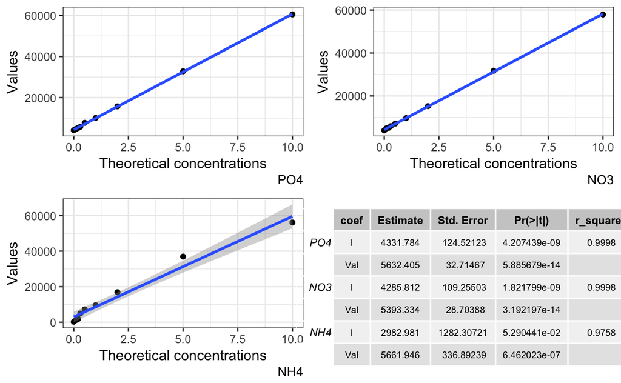

```r
# select CALB to check a good calibration line
meth_a%>%filter(type == "CALB") -> calb_a
# If ok next step, otherwise compute a new variable with best calibration line between theorical values and obtained values
#PO4
PO4_graph <- ggplot(data = calb_a, mapping = aes(x = PO4_theo, y = PO4_val))+
  geom_point()+
  geom_smooth(method = "lm") +
  labs( x = "Theoretical concentrations", y = "Values", caption = "PO4") +
  theme(plot.caption = element_text(hjust = 0.5)) +
  theme_bw()
# simply graph to visualize the calibration line for PO4
# Compute linear regression and extract r^2^ for PO4
PO4_reg <-lm(PO4_val ~ PO4_theo, data =  calb_a)
summary((PO4_reg))$coefficients -> PO4_tab
PO4_tab <- as.data.frame(PO4_tab)
round(summary((PO4_reg))$r.squared, 4) -> r_squared
PO4_tab$r_squared <- c(r_squared, " ")
# Same procedure for all elements
#NO3
NO3_graph <- ggplot(data = calb_a, mapping = aes(x = NO3_theo, y = NO3_val))+
  geom_point()+
  geom_smooth(method = "lm")+
  labs( x = "Theoretical concentrations", y = "Values", caption = "NO3")+
  theme(plot.caption = element_text(hjust = 0.5))+
  theme_bw()
NO3_reg <-lm(NO3_val ~ NO3_theo, data =  calb_a)
summary((NO3_reg))$coefficients -> NO3_tab
NO3_tab <- as.data.frame(NO3_tab)
round(summary((NO3_reg))$r.squared, 4) -> r_squared
NO3_tab$r_squared <- c(r_squared, " ")
#NH4
NH4_graph <- ggplot(data = calb_a, mapping = aes(x = NH4_theo, y = NH4_val))+
  geom_point()+
  geom_smooth(method = "lm") +
  labs( x = "Theoretical concentrations", y = "Values", caption = "NH4")+
  theme(plot.caption = element_text(hjust = 0.5))+
  theme_bw()
NH4_reg <-lm(NH4_val ~ NH4_theo, data =  calb_a)
summary((NH4_reg))$coefficients -> NH4_tab
NH4_tab <- as.data.frame(NH4_tab)
round(summary((NH4_reg))$r.squared, 4) -> r_squared
NH4_tab$r_squared <- c(r_squared, " ")
calb_tab <- bind_rows( PO4_tab, NO3_tab, NH4_tab)
calb_tab_a <- data_frame(coef= c( "I", "Val",  "I", "Val",  "I", "Val"))
calb_tab <- bind_cols(calb_tab_a, calb_tab)
## Template for tab
mytheme <- gridExtra::ttheme_default(
    core = list(fg_params=list(cex = 0.6)),
    colhead = list(fg_params=list(cex = 0.7)),
    rowhead = list(fg_params=list(cex = 0.7)))
## Create tab with lm's coefficients
tab <- tableGrob(calb_tab[ , - c(4)], theme = mytheme, rows = c("PO4", " ", "NO3", " ", "NH4", ""))
#multiplot
ggarrange(PO4_graph, NO3_graph, NH4_graph, tab)
```

```r
remove(calb_tab, calb_tab_a, mytheme, NH4_graph, NH4_reg, NH4_tab, NO3_graph, NO3_reg, NO3_tab, PO4_graph, PO4_reg, PO4_tab, tab)
```

The calibration’s lines for $PO_4$ and $NO_3$ are near to 1. The calibration’s line of $NH_4$ is lowest quality.

# Samples

```r
meth_a%>%
  filter(echant != "Primer", echant != "Drift", echant != "End") -> meth_a
meth_a$echant <- factor(meth_a$echant,
                        labels = c("0", "0.1", "0.2", "0.3", "0.5", "1", "2", "5", "10"),
                        levels = c("cal0", "cal0.1", "cal0.2", "cal0.3", "cal0.5", "cal1", "cal2", "cal5", "cal10"),
                        ordered = TRUE)
#save data only for a short presentation lab meeting
#write_rds(x = meth_a, path = "../Cache/reproductibility_metha.rds")
```

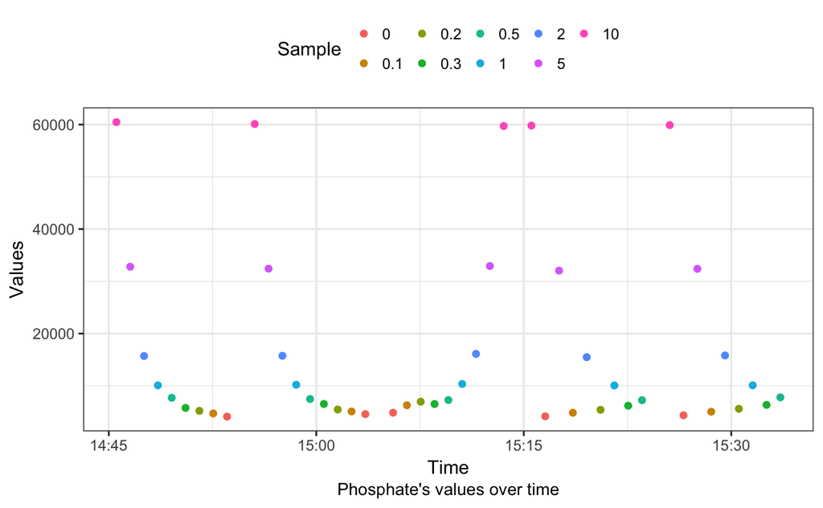

```r
ggplot(data = meth_a, mapping = aes(x = date_analyse, y = PO4_val, color = echant))+
  geom_point()  +
  labs( x = "Time", y = "Values", caption = "Phosphate's values over time", color = "Sample")+
  theme_bw() +
  theme(plot.caption = element_text(hjust = 0.5), legend.position = "top")
```

This graph shows the order of analysis’ sets on $PO_4$ that is the same for $NO_3$ and $NH_4$

## PO4

```r
meth_a %>%
  group_by(echant)%>%
  summarise(mean = mean(PO4_val),
            sd = sd(PO4_val),
            cv = round( ((sd(PO4_val)/mean(PO4_val))*100), digits = 2),
            nbre = length(PO4_val)) -> a
kable(a, format = "pandoc", caption = "Mean, standard deviation (sd) and variation coefficient (cv) of phosphate's values of different samples.")
```

Mean, standard deviation (sd) and variation coefficient (cv) of phosphate's values of different samples.

| echant | mean | sd | cv | nbre |
| --- | --- | --- | --- | --- |
| 0 | 4415.0 | 306.8811 | 6.95 | 5 |
| 0.1 | 5195.6 | 624.6369 | 12.02 | 5 |
| 0.2 | 5727.8 | 699.6329 | 12.21 | 5 |
| 0.3 | 6272.8 | 312.8861 | 4.99 | 5 |
| 0.5 | 7498.8 | 245.7655 | 3.28 | 5 |
| 1 | 10164.0 | 119.0903 | 1.17 | 5 |
| 2 | 15775.0 | 226.5624 | 1.44 | 5 |
| 5 | 32514.2 | 347.0356 | 1.07 | 5 |
| 10 | 59994.4 | 298.7571 | 0.50 | 5 |

The variation coefficient is too high below $0.2 \ \mu mol/L$.

## NO3

```r
meth_a %>%
  group_by(echant)%>%
  summarise(mean = mean(NO3_val),
            sd = sd(NO3_val),
            cv = round( ((sd(NO3_val)/mean(NO3_val))*100), digits = 2),
            nbre = length(NO3_val)) -> a
kable(a, format = "pandoc", caption = "Mean, standard deviation (sd) and variation coefficient (cv) of nitrate's values of different samples.")
```

Mean, standard deviation (sd) and variation coefficient (cv) of nitrate's values of different samples.

| echant | mean | sd | cv | nbre |
| --- | --- | --- | --- | --- |
| 0 | 4092.0 | 115.1021 | 2.81 | 5 |
| 0.1 | 4766.0 | 220.8110 | 4.63 | 5 |
| 0.2 | 5270.6 | 281.5507 | 5.34 | 5 |
| 0.3 | 5926.2 | 301.3490 | 5.09 | 5 |
| 0.5 | 7224.6 | 514.9284 | 7.13 | 5 |
| 1 | 9766.6 | 190.4148 | 1.95 | 5 |
| 2 | 15718.2 | 528.2989 | 3.36 | 5 |
| 5 | 32168.0 | 763.1668 | 2.37 | 5 |
| 10 | 58193.2 | 212.2774 | 0.36 | 5 |

The variation coefficient is too high below $0.5 \ \mu mol/L$.

## NH4

```r
meth_a %>%
  group_by(echant)%>%
  summarise(mean = mean(NH4_val),
            sd = sd(NH4_val),
            cv = round( ((sd(NH4_val)/mean(NH4_val))*100), digits = 2),
            nbre = length(NH4_val)) -> a
kable(a, format = "pandoc", caption = "Mean, standard deviation (sd) and variation coefficient (cv) of nitrate's values of different samples.")
```

| echant | mean | sd | cv | nbre |
| --- | --- | --- | --- | --- |
| 0 | 225.2 | 161.0456 | 71.51 | 5 |
| 0.1 | 831.8 | 488.3551 | 58.71 | 5 |
| 0.2 | 1694.8 | 1408.1808 | 83.09 | 5 |
| 0.3 | 2820.8 | 1250.3196 | 44.33 | 5 |
| 0.5 | 5555.4 | 1342.7121 | 24.17 | 5 |
| 1 | 8168.0 | 938.5166 | 11.49 | 5 |
| 2 | 14126.2 | 1931.4500 | 13.67 | 5 |
| 5 | 36977.2 | 316.9333 | 0.86 | 5 |
| 10 | 56170.0 | 174.8199 | 0.31 | 5 |

The variation coefficient is too high below $2 \ \mu mol/L$.

# Discussion & perspective

It is possible that the samples deteriorate over time.

This experiment must be achived with the same protocol on method B.